# BIOS 6624 : Project 0

Ryan Summers

2026-01-22

## Read in the csv

```r
spit_raw <- read_csv("/Users/ryan_summers/GitHub/BIOS6624-Class/Project0/DataRaw/Project0_Clean_v2.csv")
# number of subjects
length(unique(spit_raw$SubjectID))
```

```
## [1] 31
```

```r
# number of missing measurements per collection sample
spit_raw %>%
  #filter(`Collection Sample` != 1) %>%
  #group_by(`Collection Sample`) %>%
  summarise(
    bk_miss = sum(is.na(`Booket: Clock Time`)),
    mem_miss = sum(is.na(`MEMs: Clock Time`)),
    n_obs = n(),
    `bk_%` = bk_miss/n_obs,
    `mem_%` = mem_miss/n_obs)
```

```
## # A tibble: 1 × 5
##   bk_miss mem_miss n_obs `bk_%` `mem_%`
##     <int>    <int> <int>  <dbl>   <dbl>
## 1      35       61   372 0.0941   0.164
```

## Data Management & Cleanup

```r
# clean up the column names
spit_df <- spit_raw %>%
  # lowercase columns & rows
  setNames(tolower(names(.))) %>%
  mutate_if(is.character, tolower) %>%
  # remove white-space in columns
  setNames(gsub("\\s+", "_", names(.)))
```

```r
spit_df <- spit_df %>%
  mutate(
    # get weekday for collection dates
    collection_date = as.Date(collection_date, format = "%m/%d/%Y"),
    weekday = weekdays(collection_date),
    # determine if weekday is the weekend
    weekend = factor(if_else(weekday %in% c("Saturday","Sunday"),
                             "Weekend", "Weekday")),
    # add zeroes for MEMS collection on 1st sample
    `mems:_sample_interval_decimal_time_(mins)` =
      ifelse(collection_sample == 1, 0,
             `mems:_sample_interval_decimal_time_(mins)`),
    # log transform responses
    log_cortisol = log(`cortisol_(nmol/l)`),
    log_dhea = log(`dhea_(nmol/l)`),
    # calculate time differences between book and MEM
    time_diff_min = as.numeric(difftime(`booket:_clock_time`,
                                         `mems:_clock_time`, units = "mins")),
    interval_diff_min = `booklet:_sample_interval_decimal_time_(mins)` -
      `mems:_sample_interval_decimal_time_(mins)`)
```

Create a datetime variable that merges the collection date and booklet clock time. * Use this variable as an anchor to determine minutest since wake-up * Additionally, create a column that stores either booklet or MEM clock time based on whether booklet contains a missing value. **Debate whether this should be used in analysis**

```r
spit_df <- spit_df %>%
  mutate(
    # create a variable that includes the date and clock time for booklet and MEMs
    bk_dt = as.POSIXct(paste(collection_date, `booket:_clock_time`),
                            format = "%Y-%m-%d %H:%M", tz = "UTC"),
    mems_dt    = as.POSIXct(paste(collection_date, `mems:_clock_time`),
                            format = "%Y-%m-%d %H:%M", tz = "UTC")) %>%

group_by(subjectid, collection_date) %>%

  mutate(
    # use wake time determined by sleep diary as PI noted
    diary_wake_time = as.POSIXct(
      paste(collection_date, sleep_diary_reported_wake_time),
      format = "%Y-%m-%d %H:%M", tz = "UTC"),
    # fill down datetime values for each subject on each day
    diary_wake_time = fill(data.frame(diary_wake_time),
                    diary_wake_time,
                    .direction = "down")$diary_wake_time,

    # extract collection times from booklet, if NA grab MEMs
    sample_dt = coalesce(`booket:_clock_time`, `mems:_clock_time`),
    dt_source = if_else(!is.na(`booket:_clock_time`), "Booklet", "MEMS"),

    # calculate time since waking for both booklet and MEMs from diary start
    bk_min_since_wk = as.numeric(difftime(bk_dt, diary_wake_time,
                                          units = "mins")),
    mem_min_since_wk = as.numeric(difftime(mems_dt, diary_wake_time,
                                           units = "mins"))) %>%
  ungroup()
```

Indicate whether Samples 2 and 4 are within 7.5min and 15min acceptance windows for adherence

```r
targets <- c(`2` = 30, `4` = 600)

spit_df2 <- spit_df %>%
  #filter(collection_sample %in% c(2, 4)) %>%
  mutate(
    target_min = targets[as.character(collection_sample)],
    good_bk    = abs(bk_min_since_wk - target_min) <= 7.5,
    adeq_bkt = abs(bk_min_since_wk - target_min) <= 15,
    good_mem    = abs(mem_min_since_wk - target_min) <= 7.5,
    adeq_mem = abs(mem_min_since_wk - target_min) <= 15)

spit_df2 <- spit_df %>%
  mutate(
    target_min = case_when(
      collection_sample == 2 ~ 30,
      collection_sample == 4 ~ 600,
      TRUE ~ NA_real_),
    # booklet times
    good_bk = if_else(
      !is.na(target_min),
      abs(bk_min_since_wk - target_min) <= 7.5,
      NA),
    adeq_bkt = if_else(
      !is.na(target_min),
      abs(bk_min_since_wk - target_min) <= 15,
      NA),
    # MEM times
    good_mem = if_else(
      !is.na(target_min),
      abs(mem_min_since_wk - target_min) <= 7.5,
      NA),
    adeq_mem = if_else(
      !is.na(target_min),
      abs(mem_min_since_wk - target_min) <= 15,
      NA))
```

## Missing Data Analysis

```r
# number of NAs
lapply(spit_df, function(x) sum(is.na(x)))
```

```
## $subjectid
## [1] 0
##
## $collection_date
## [1] 0
##
## $collection_sample
## [1] 0
##
## $`booket:_clock_time`
## [1] 35
##
## $`mems:_clock_time`
## [1] 61
##
## $sleep_diary_reported_wake_time
## [1] 279
##
## $`booklet:_sample_interval`
## [1] 130
##
## $`booklet:_sample_interval_decimal_time_(mins)`
## [1] 55
##
## $`mems:_sample_interval`
## [1] 177
##
## $`mems:_sample_interval_decimal_time_(mins)`
## [1] 84
##
## $`cortisol_(ug/dl)`
## [1] 0
##
## $`dhea_(pg/dl)`
## [1] 5
##
## $`cortisol_(nmol/l)`
## [1] 5
##
## $`dhea_(nmol/l)`
```

[output cut: 28 more lines]

```
##
## $diary_wake_time
## [1] 0
##
## $sample_dt
## [1] 9
##
## $dt_source
## [1] 0
##
## $bk_min_since_wk
## [1] 35
##
## $mem_min_since_wk
## [1] 61
```

```r
spit_df %>%
  ungroup() %>%
  #group_by(collection_sample) %>%
  select(`booket:_clock_time`, `mems:_clock_time`, `cortisol_(ug/dl)`, `dhea_(pg/dl)`,
         `cortisol_(nmol/l)`, `dhea_(nmol/l)`) %>%
  miss_var_summary()
```

```
## # A tibble: 6 × 3
##   variable           n_miss pct_miss
##   <chr>               <int>    <num>
## 1 mems:_clock_time       61    16.4
## 2 booket:_clock_time     35     9.41
## 3 dhea_(pg/dl)            5     1.34
## 4 cortisol_(nmol/l)       5     1.34
## 5 dhea_(nmol/l)           5     1.34
## 6 cortisol_(ug/dl)        0     0
```

## Address PI’s question about agreement between the subject’s recordings of sampling times compared to the times recorded by an electronic monitoring cap (1)

Scatter-plot of agreement (stratify by collection sample) for PI

```r
cor_by_sample <- spit_df %>%
  filter(!is.na(mem_min_since_wk), !is.na(bk_min_since_wk)) %>%
  group_by(collection_sample) %>%
  summarise(
    r = cor(mem_min_since_wk, bk_min_since_wk),
    p = cor.test(mem_min_since_wk, bk_min_since_wk)$p.value)

cor_by_sample
```

```
## # A tibble: 4 × 3
##   collection_sample      r        p
##               <dbl>  <dbl>    <dbl>
## 1                 1 0.0734 5.40e- 1
## 2                 2 0.125  3.18e- 1
## 3                 3 0.853  5.13e-22
## 4                 4 0.945  3.07e-36
```

```r
# # plot scatterplots for each collection sample along w/pearson
# ggplot(spit_df, aes(x = `mems:_clock_time`, y = `booket:_clock_time`)) +
#   geom_point(alpha = 0.5) +
#   geom_abline(slope = 1, intercept = 0, linetype = 2, color = "firebrick3") +
#   facet_wrap(~ collection_sample) +
#   stat_cor(
#     method = "pearson",
#     label.x.npc = "left",
#     label.y.npc = "top",
#     size = 3) +
#   labs(
#     title = "Booklet vs Cap Collection Time by Sample",
#     x = "Cap minutes since wake",
#     y = "Booklet minutes since wake") +
#   theme_minimal(base_size = 10)
```

Mixed Model: Is there bias in self-reported times, and does it differ by sample, accounting for repeated measurements within subjects?

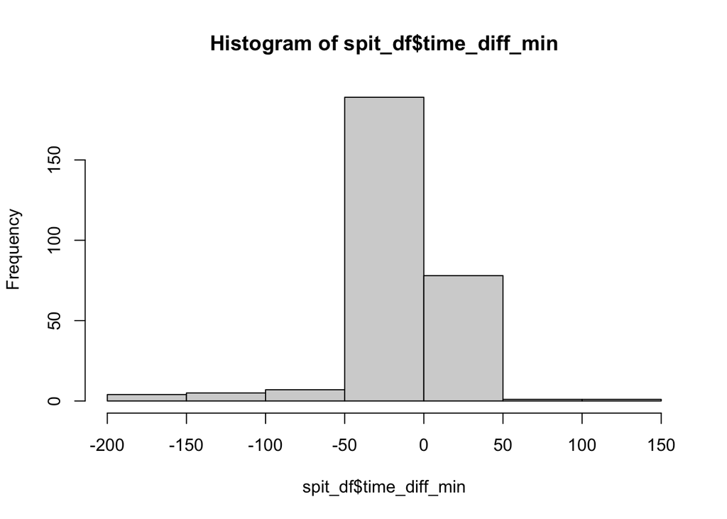

```r
# convert collection sample to factor and create labels for it
spit_df$collection_sample <- factor(
  spit_df$collection_sample,
  labels = c(
    "Wake",
    "+30min",
    "Before lunch",
    "+600min"))

hist(spit_df$time_diff_min)
```

```r
summary(spit_df$time_diff_min)
```

```
##     Min.  1st Qu.   Median     Mean  3rd Qu.     Max.     NA's
## -200.000   -7.000   -1.000   -7.712    1.000  133.000       87
```

```r
## booklet minus mem as outcome
## remove intercept so we are conducting t-tests that each collection time is
## different from zero
agrmnt.model <- lmer(
  time_diff_min ~ 0 + collection_sample + (1 | subjectid),
  data = spit_df)

summary(agrmnt.model)
```

```
## Linear mixed model fit by REML. t-tests use Satterthwaite's method [
## lmerModLmerTest]
## Formula: time_diff_min ~ 0 + collection_sample + (1 | subjectid)
##    Data: spit_df
##
## REML criterion at convergence: 2759
##
## Scaled residuals:
##     Min      1Q  Median      3Q     Max
## -6.0659  0.0084  0.1101  0.3667  4.3412
##
## Random effects:
##  Groups    Name        Variance Std.Dev.
##  subjectid (Intercept)  47.96    6.925
##  Residual              973.36   31.199
## Number of obs: 285, groups:  subjectid, 31
##
## Fixed effects:
##                               Estimate Std. Error      df t value Pr(>|t|)
## collection_sampleWake           -4.118      3.912 158.733  -1.053    0.294
## collection_sample+30min        -16.281      4.072 171.581  -3.998 9.48e-05 ***
## collection_sampleBefore lunch   -6.240      3.853 161.285  -1.619    0.107
## collection_sample+600min        -5.589      3.874 165.676  -1.443    0.151
## ---
## Signif. codes:  0 '***' 0.001 '**' 0.01 '*' 0.05 '.' 0.1 ' ' 1
##
## Correlation of Fixed Effects:
##             cllc_W cl_+30 cll_Bl
## cllctn_s+30 0.106
## cllctn_smBl 0.112  0.106
## cllctn_+600 0.108  0.099  0.108
```

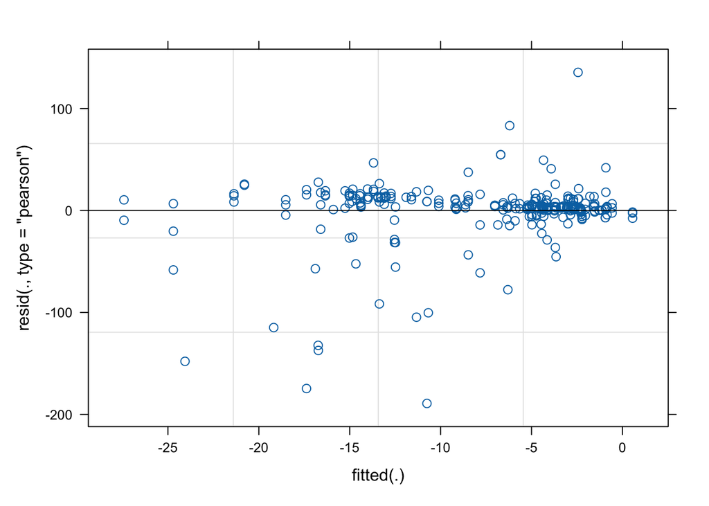

```r
# check residuals to determine if skewness is too extreme for this model approach
plot(agrmnt.model)   # residuals vs fitted
```

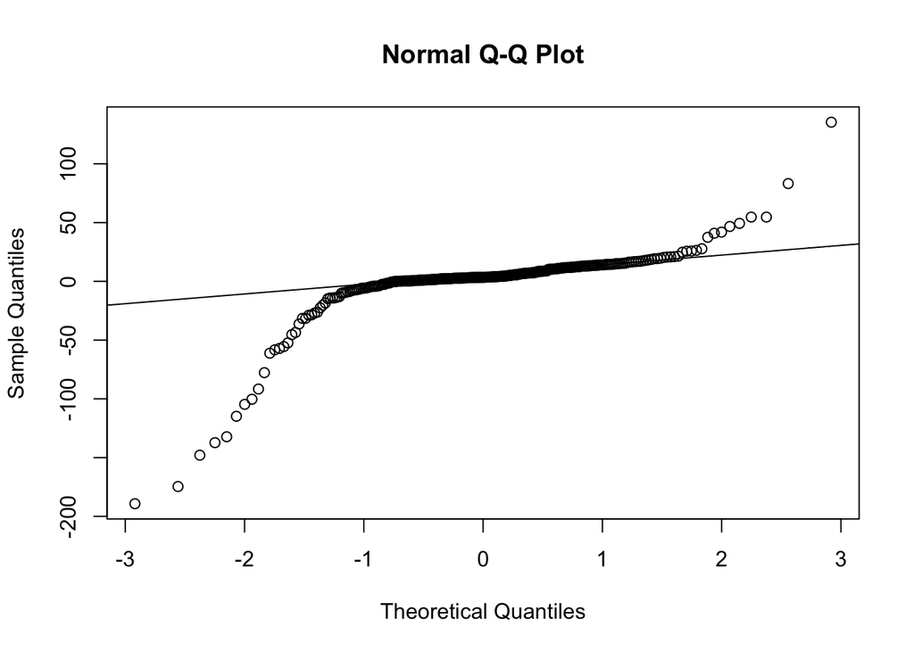

```r
qqnorm(resid(agrmnt.model)); qqline(resid(agrmnt.model))
```

```r
# try different methods of estimating SEs
confint(agrmnt.model, method = "boot")
```

```
## Computing bootstrap confidence intervals ...
```

```
##
## 48 message(s): boundary (singular) fit: see help('isSingular')
```

```
##                                   2.5 %    97.5 %
## .sig01                          0.00000 11.207292
## .sigma                         28.57689 33.991113
## collection_sampleWake         -11.29921  3.685024
## collection_sample+30min       -24.36982 -7.301522
## collection_sampleBefore lunch -13.91624  1.204674
## collection_sample+600min      -13.53203  2.100894
```

```r
library(clubSandwich)
coef_test(agrmnt.model, vcov = "CR2")
```

```
## Alternative hypothesis: two-sided
##                          Coef. Estimate   SE Null value t-stat d.f. (Satt)
##          collection_sampleWake    -4.12 1.53          0  -2.70        25.3
##        collection_sample+30min   -16.28 5.10          0  -3.19        24.3
##  collection_sampleBefore lunch    -6.24 4.95          0  -1.26        27.0
##       collection_sample+600min    -5.59 3.19          0  -1.75        27.3
##  p-val (Satt) Sig.
##        0.0122    *
##        0.0039   **
##        0.2184
##        0.0909    .
```

The distribution of errors are heavily skewed in the tails. Perhaps this modelling approach can still be used but be more descriptive?? * any transformation to the time difference outcome would make interpretation difficult due to the occurrence of zeros, which prevents a log-transform. * can use boot-strap or robust erros method but this making it more complicated than it needs to be

```r
# table for model using collection sample as a fixed effect
tbl_regression(
  agrmnt.model,
  intercept = T,
  estimate_fun = label_style_sigfig(digits = 3),
  pvalue_fun = label_style_pvalue(digits = 3),
    label = list(
    collection_sample ~ "Collection Sample")) %>%
  as_gt() %>%
  gt::tab_header(title = "Agreement Between Booklet vs Cap",
                 subtitle = "LMM w/ Random Intercept") %>%
    tab_options(
      table.width = pct(55),
    table.font.size = "small",
    data_row.padding = px(3),
    table.border.top.width = px(2),
    table.border.bottom.width = px(2))
```

Agreement Between Booklet vs Cap

LMM w/ Random Intercept

| **Characteristic** | **Beta** | **95% CI** | **p-value** |
| --- | --- | --- | --- |
| Collection Sample |  |  |  |
| Wake | -4.12 | -11.8, 3.61 | 0.294 |
| +30min | -16.3 | -24.3, -8.24 | <0.001 |
| Before lunch | -6.24 | -13.8, 1.37 | 0.107 |
| +600min | -5.59 | -13.2, 2.06 | 0.151 |

Abbreviation: CI = Confidence Interval

```r
# class recommended one - **debatable**
agrmnt.model2 <- lmer(
  bk_min_since_wk ~  mem_min_since_wk + (1 | subjectid),
  data = spit_df)

summary(agrmnt.model2)
```

```
## Linear mixed model fit by REML. t-tests use Satterthwaite's method [
## lmerModLmerTest]
## Formula: bk_min_since_wk ~ mem_min_since_wk + (1 | subjectid)
##    Data: spit_df
##
## REML criterion at convergence: 2787.7
##
## Scaled residuals:
##     Min      1Q  Median      3Q     Max
## -5.9420  0.0024  0.1588  0.2635  4.3866
##
## Random effects:
##  Groups    Name        Variance Std.Dev.
##  subjectid (Intercept)  44.11    6.642
##  Residual              989.60   31.458
## Number of obs: 285, groups:  subjectid, 31
##
## Fixed effects:
##                   Estimate Std. Error        df t value Pr(>|t|)
## (Intercept)       -6.50779    2.91608  66.29918  -2.232    0.029 *
## mem_min_since_wk   0.99494    0.00706 262.91666 140.931   <2e-16 ***
## ---
## Signif. codes:  0 '***' 0.001 '**' 0.01 '*' 0.05 '.' 0.1 ' ' 1
##
## Correlation of Fixed Effects:
##             (Intr)
## mm_mn_snc_w -0.641
```

```r
library(car)
# test that beta=0 (bias) & beta1=1 (agreement)
# conducts a wald test
  # How far is est param from the hypothesized value, relative to its est variability?
car::linearHypothesis(agrmnt.model2,
                      c("(Intercept) = 0",
                        "mem_min_since_wk = 1"))
```

```
##
## Linear hypothesis test:
## (Intercept) = 0
## mem_min_since_wk = 1
##
## Model 1: restricted model
## Model 2: bk_min_since_wk ~ mem_min_since_wk + (1 | subjectid)
##
##   Df  Chisq Pr(>Chisq)
## 1
## 2  2 12.813   0.001651 **
## ---
## Signif. codes:  0 '***' 0.001 '**' 0.01 '*' 0.05 '.' 0.1 ' ' 1
```

```r
# table for simple linear association between timing methods
tbl_regression(
  agrmnt.model2,
  intercept = T,
  estimate_fun = label_style_sigfig(digits = 3),
  pvalue_fun = label_style_pvalue(digits = 3),
    label = list(
      `(Intercept)` ~ "Intercept",
    mem_min_since_wk ~ "Cap min since waking")) %>%
  as_gt() %>%
  gt::tab_header(title = "Agreement Between Booklet vs Cap",
                 subtitle = "LMM w/ Random Intercept") %>%
    tab_options(
      table.width = pct(55),
    table.font.size = "small",
    data_row.padding = px(3),
    table.border.top.width = px(2),
    table.border.bottom.width = px(2))
```

Agreement Between Booklet vs Cap

LMM w/ Random Intercept

| **Characteristic** | **Beta** | **95% CI** | **p-value** |
| --- | --- | --- | --- |
| Intercept | -6.51 | -12.3, -0.686 | 0.029 |
| Cap min since waking | 0.995 | 0.981, 1.01 | <0.001 |

Abbreviation: CI = Confidence Interval

Intercept should be zero and slope should be 1. *IF agreement exists*

Correlation is invariant to shifts: * If Booklet times are always 10 minutes later than Cap, correlation can still be ~1.0. * High correlation does not mean there is no bias; the mixed model identifies a consistent bias at Sample 2 after accounting for subject-level variability.

```r
# extract observations actually used by model (excludes NAs in model)
df_used <- model.frame(agrmnt.model2)

# beta coefficients
betas <- fixef(agrmnt.model2)

fit <- predict(agrmnt.model2, re.form = NA)
se <- predict(agrmnt.model2, re.form = NA, se.fit = TRUE)$se.fit
lower <- fit - 1.96 * se
upper <- fit + 1.96 * se

pred_df <- df_used %>%
  dplyr::mutate(
    fit = fit,
    lower = lower,
    upper = upper)

# model equation for plotting
eq_label <- sprintf(
  "italic(y) == %.2f %s %.2f*italic(x)",
  betas[1],
  ifelse(betas[2] < 0, "-", "+"),
  abs(betas[2]))
```

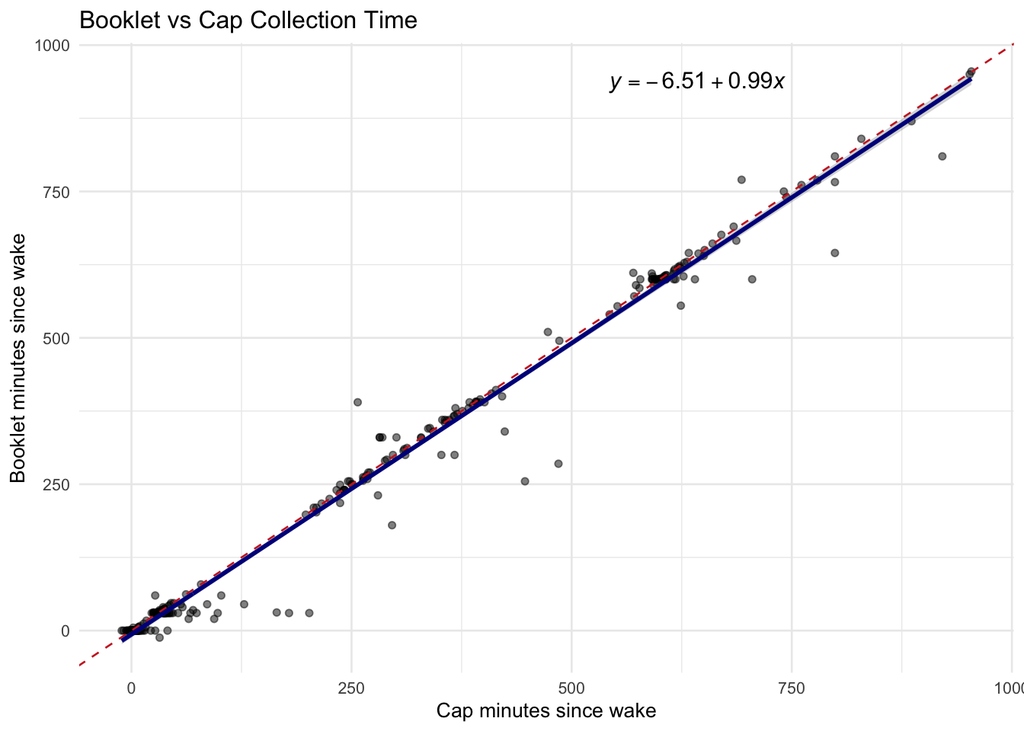

```r
ggplot() +
  geom_point(
    data = spit_df,
    aes(x = mem_min_since_wk, y = bk_min_since_wk),
    alpha = 0.5) +
  geom_abline(slope = 1, intercept = 0,
              linetype = 2, color = "firebrick3") +

  geom_ribbon(
    data = pred_df,
    aes(x = mem_min_since_wk, ymin = lower, ymax = upper),
    fill = "gray35", alpha = 0.25) +

  geom_line(
    data = pred_df %>% dplyr::arrange(mem_min_since_wk),
    aes(x = mem_min_since_wk, y = fit),
    color = "darkblue", linewidth = 1) +

  annotate(
    "text",
    x = 752, y = 900,
    label = eq_label,
    parse = T,
    hjust = 1.05, vjust = -0.5,
    size = 4) +

  labs(
    title = "Booklet vs Cap Collection Time",
    x = "Cap minutes since wake",
    y = "Booklet minutes since wake") +
  theme_minimal(base_size = 10)
```

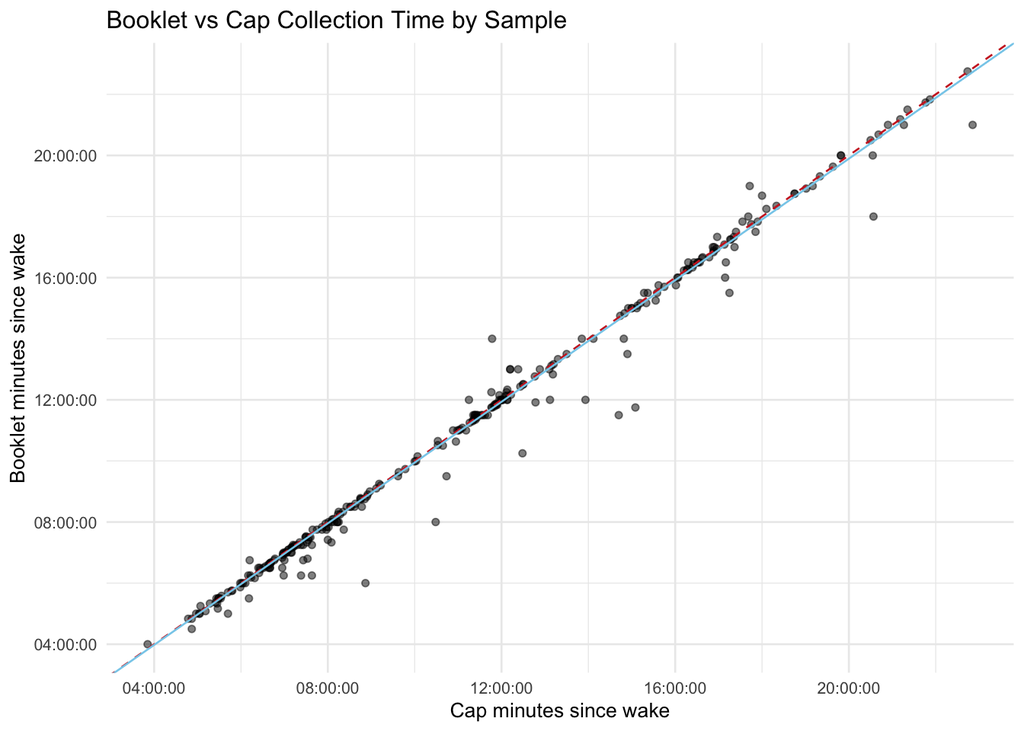

```r
# plot scatterplots w/ fitted model line
ggplot(spit_df, aes(x = `mems:_clock_time`, y = `booket:_clock_time`)) +
  geom_point(alpha = 0.5) +
  # perfect agreement line
  geom_abline(slope = 1, intercept = 0, linetype = 2, color = "firebrick3") +
  geom_abline(slope = betas[2], intercept = betas[1], color="skyblue") +
  labs(
    title = "Booklet vs Cap Collection Time by Sample",
    x = "Cap minutes since wake",
    y = "Booklet minutes since wake") +
  theme_minimal(base_size = 10)
```

## Address PI’s question about adhering to +30min and 600min sampling times (2)

and create a table 1 (Descriptive Table)

Create table1

```r
# variables used to remove NA calculation for samples 1 and 3
adherence_vars <- c("good_bk", "adeq_bkt", "good_mem", "adeq_mem")

tbl1 <- spit_df2 %>%
  mutate(
    collection_sample = factor(
      collection_sample,
      levels = c(1, 2, 3, 4),
      labels = c(
        "Wake",
        "+30 min",
        "Before lunch",
        "+600 min"))) %>%
  ungroup() %>%
  select(
    time_diff_min,
    collection_sample,
    `dhea_(nmol/l)`,
    `cortisol_(nmol/l)`,
    good_bk,
    adeq_bkt,
    good_mem,
    adeq_mem ) %>%

  tbl_summary(
    by = collection_sample,
    type = all_continuous() ~ "continuous2",
    statistic = list(
      all_continuous() ~ c(
        "{mean} ({sd})",
        "{median} ({p25}, {p75})",
        "{min} - {max}"),
      all_categorical() ~ "{p}%"),

    digits = all_continuous() ~ 1,
    missing = "ifany",
    missing_text = "NA",
    missing_stat = "{p_miss}%",

    # change variable names
    label = list(
      time_diff_min ~ "Booklet vs Cap Time (min)",
    `dhea_(nmol/l)` ~ "DHEA (nmol/L)"  ,
    `cortisol_(nmol/l)` ~ "Cortisol (nmol/L)",
    good_bk  ~ "Booklet (±7.5 min)",
    adeq_bkt  ~ "Booklet (±15 min)",
    good_mem ~ "Cap (±7.5 min)",
    adeq_mem ~ "Cap (±15 min)"
    )) %>%
  add_overall() %>%
    modify_table_body(
    ~ .x %>%
      mutate(
        across(
          starts_with("stat_"),
          ~ if_else(
            # only replace NA-looking output for categorical rows / missing rows,
            # and NOT for continuous variables (continuous2 multi-line rows)
            var_type != "continuous" &
              row_type %in% c("level", "missing") &
              (is.na(.) | str_detect(., "^NA")), "—", .)))) %>%

    modify_table_body(
    ~ .x %>%
      mutate(
        # remove Overall NA calculation for adherence variables (misleading to have)
        stat_0 = if_else(row_type == "missing" & variable %in% adherence_vars,
                         "—", stat_0),
        # remove NA calculation for collection 1 and 3
        stat_1 = if_else(row_type == "missing" & variable %in% adherence_vars,
                         "—", stat_1),
        stat_3 = if_else(row_type == "missing" & variable %in% adherence_vars,
                         "—", stat_3))) %>%

    modify_table_body(
    ~ .x %>%
      mutate(
        across(
          starts_with("stat_"),
          ~ if_else(
            # Only touch adherence variables, any row type,
            # and replace anything that is NA / starts with NA (e.g., NA%, NA (NA%))
            variable %in% adherence_vars & (is.na(.) | str_detect(., "^NA")),
            "—", .)))) %>%
  bold_labels() %>%
  italicize_levels() %>%
  add_p(pvalue_fun = label_style_pvalue(digits = 2)) %>%
  modify_spanning_header(
    c("stat_1", "stat_2", "stat_3", "stat_4") ~ "**Collection Sample**") %>%
  modify_footnote_header(
    footnote = "Table includes all subject from cohort",
    columns = all_stat_cols(),
    replace = FALSE) %>%
  # # kable extra helps with fitting tables within margins of PDF
  # as_kable_extra(format = "latex") %>%
  # kableExtra::kable_styling(
  #   latex_options = c("hold_position", "scale_down", "repeat_header"),
  #   font_size = 8)
  # gt is better looking overall
  as_gt() %>%
  tab_options(
    table.font.size = "small",
    heading.align = "left",
    data_row.padding = px(3),
    table.border.top.width = px(2),
    table.border.bottom.width = px(2))


tbl1
```

| **Characteristic** | **Overall** N = 372<sup>1,2</sup> | **Collection Sample** **Wake** N = 93<sup>1,2</sup> | **Collection Sample** **+30 min** N = 93<sup>1,2</sup> | **Collection Sample** **Before lunch** N = 93<sup>1,2</sup> | **Collection Sample** **+600 min** N = 93<sup>1,2</sup> | **p-value**<sup>3</sup> |  |
| --- | --- | --- | --- | --- | --- | --- | --- |
| Booklet vs Cap Time (min) |  |  |  |  |  |  | 0.015 |
| Mean (SD) | -7.7 (32.1) | -4.0 (8.7) | -16.0 (35.9) | -6.2 (42.7) | -5.4 (29.9) |  |  |
| Median (Q1, Q3) | -1.0 (-7.0, 1.0) | -2.0 (-6.0, -0.5) | -1.0 (-13.0, 0.0) | -1.0 (-3.0, 3.0) | 0.0 (-4.0, 4.0) |  |  |
| Min - Max | -200.0 - 133.0 | -44.0 - 11.0 | -172.0 - 33.0 | -200.0 - 133.0 | -154.0 - 77.0 |  |  |
| NA | 23% | 23% | 29% | 20% | 22% |  |  |
| DHEA (nmol/L) |  |  |  |  |  | <0.001 |  |
| Mean (SD) | 1.0 (1.0) | 1.8 (1.3) | 1.1 (0.9) | 0.5 (0.5) | 0.5 (0.6) |  |  |
| Median (Q1, Q3) | 0.6 (0.3, 1.3) | 1.6 (0.8, 2.4) | 0.9 (0.5, 1.4) | 0.4 (0.2, 0.6) | 0.3 (0.2, 0.5) |  |  |
| Min - Max | 0.1 - 5.2 | 0.1 - 5.2 | 0.1 - 5.2 | 0.1 - 2.8 | 0.1 - 3.6 |  |  |
| NA | 1.3% | 0% | 1.1% | 2.2% | 2.2% |  |  |
| Cortisol (nmol/L) |  |  |  |  |  | <0.001 |  |
| Mean (SD) | 6.0 (6.9) | 7.4 (6.0) | 9.0 (4.9) | 3.2 (2.3) | 4.2 (10.3) |  |  |
| Median (Q1, Q3) | 4.1 (2.0, 7.7) | 5.4 (3.9, 8.2) | 8.8 (5.9, 11.4) | 2.8 (1.4, 4.3) | 2.0 (1.0, 3.3) |  |  |
| Min - Max | 0.5 - 89.6 | 0.5 - 29.2 | 0.5 - 25.5 | 0.5 - 13.1 | 0.5 - 89.6 |  |  |
| NA | 1.3% | 0% | 1.1% | 2.2% | 2.2% |  |  |
| Booklet (±7.5 min) | 63% | — | 78% | — | 46% | <0.001 |  |
| NA | — | — | 6.5% | — | 14% |  |  |
| Booklet (±15 min) | 74% | — | 90% | — | 56% | <0.001 |  |
| NA | — | — | 6.5% | — | 14% |  |  |
| Cap (±7.5 min) | 42% | — | 53% | — | 33% | 0.014 |  |
| NA | — | — | 25% | — | 11% |  |  |
| Cap (±15 min) | 54% | — | 71% | — | 40% | <0.001 |  |
| NA | — | — | 25% | — | 11% |  |  |

<sup>1</sup> %  
<sup>2</sup> Table includes all subject from cohort  
<sup>3</sup> Kruskal-Wallis rank sum test; Fisher’s exact test

```r
# variables used to remove NA calculation for samples 1 and 3
adherence_vars <- c("good_bk", "adeq_bkt", "good_mem", "adeq_mem")

tbl1 <- spit_df2 %>%
  mutate(
    collection_sample = factor(
      collection_sample,
      levels = c(1, 2, 3, 4),
      labels = c(
        "Wake",
        "+30 min",
        "Before lunch",
        "+600 min"))) %>%
  ungroup() %>%
  select(
    collection_sample,
    good_bk,
    adeq_bkt,
    good_mem,
    adeq_mem ) %>%

  tbl_summary(
    by = collection_sample,
    type = all_continuous() ~ "continuous2",
    statistic = list(
      all_continuous() ~ c(
        "{mean} ({sd})",
        "{median} ({p25}, {p75})",
        "{min} - {max}"),
      all_categorical() ~ "{p}%"),

    digits = all_continuous() ~ 1,
    missing = "ifany",
    missing_text = "NA",
    missing_stat = "{p_miss}%",

    # change variable names
    label = list(
    good_bk  ~ "Booklet (±7.5 min)",
    adeq_bkt  ~ "Booklet (±15 min)",
    good_mem ~ "Cap (±7.5 min)",
    adeq_mem ~ "Cap (±15 min)"
    )) %>%
  add_overall() %>%
    modify_table_body(
    ~ .x %>%
      mutate(
        across(
          starts_with("stat_"),
          ~ if_else(
            # only replace NA-looking output for categorical rows / missing rows,
            # and NOT for continuous variables (continuous2 multi-line rows)
            var_type != "continuous" &
              row_type %in% c("level", "missing") &
              (is.na(.) | str_detect(., "^NA")), "—", .)))) %>%

    modify_table_body(
    ~ .x %>%
      mutate(
        # remove Overall NA calculation for adherence variables (misleading to have)
        stat_0 = if_else(row_type == "missing" & variable %in% adherence_vars,
                         "—", stat_0),
        # remove NA calculation for collection 1 and 3
        stat_1 = if_else(row_type == "missing" & variable %in% adherence_vars,
                         "—", stat_1),
        stat_3 = if_else(row_type == "missing" & variable %in% adherence_vars,
                         "—", stat_3))) %>%

    modify_table_body(
    ~ .x %>%
      mutate(
        across(
          starts_with("stat_"),
          ~ if_else(
            # Only touch adherence variables, any row type,
            # and replace anything that is NA / starts with NA (e.g., NA%, NA (NA%))
            variable %in% adherence_vars & (is.na(.) | str_detect(., "^NA")),
            "—", .)))) %>%
  bold_labels() %>%
  italicize_levels() %>%
  add_p(pvalue_fun = label_style_pvalue(digits = 2)) %>%
  modify_spanning_header(
    c("stat_1", "stat_2", "stat_3", "stat_4") ~ "**Collection Sample**") %>%
  modify_footnote_header(
    footnote = "Table includes all subject from cohort",
    columns = all_stat_cols(),
    replace = FALSE) %>%
  # # kable extra helps with fitting tables within margins of PDF
  # as_kable_extra(format = "latex") %>%
  # kableExtra::kable_styling(
  #   latex_options = c("hold_position", "scale_down", "repeat_header"),
  #   font_size = 8)
  # gt is better looking overall
  as_gt() %>%
  tab_options(
    table.font.size = "small",
    heading.align = "left",
    data_row.padding = px(3),
    table.border.top.width = px(2),
    table.border.bottom.width = px(2))


tbl1
```

| **Characteristic** | **Overall** N = 372<sup>1,2</sup> | **Collection Sample** **Wake** N = 93<sup>1,2</sup> | **Collection Sample** **+30 min** N = 93<sup>1,2</sup> | **Collection Sample** **Before lunch** N = 93<sup>1,2</sup> | **Collection Sample** **+600 min** N = 93<sup>1,2</sup> | **p-value**<sup>3</sup> |  |
| --- | --- | --- | --- | --- | --- | --- | --- |
| Booklet (±7.5 min) | 63% | — | 78% | — | 46% |  | <0.001 |
| NA | — | — | 6.5% | — | 14% |  |  |
| Booklet (±15 min) | 74% | — | 90% | — | 56% | <0.001 |  |
| NA | — | — | 6.5% | — | 14% |  |  |
| Cap (±7.5 min) | 42% | — | 53% | — | 33% | 0.014 |  |
| NA | — | — | 25% | — | 11% |  |  |
| Cap (±15 min) | 54% | — | 71% | — | 40% | <0.001 |  |
| NA | — | — | 25% | — | 11% |  |  |

<sup>1</sup> %  
<sup>2</sup> Table includes all subject from cohort  
<sup>3</sup> Fisher’s exact test

```r
# instances where there is no booklet or mem time recorded but cortisol/dhea
# levels are recorded
spit_df2 %>%
  filter(is.na(`booket:_clock_time`) & is.na(`mems:_clock_time`))
```

```
## # A tibble: 9 × 33
##   subjectid collection_date collection_sample `booket:_clock_time`
##       <dbl> <date>                      <dbl> <time>
## 1      3019 2018-10-03                      3    NA
## 2      3021 2018-10-21                      4    NA
## 3      3028 2018-10-22                      3    NA
## 4      3029 2018-10-07                      4    NA
## 5      3030 2018-11-06                      3    NA
## 6      3038 2018-10-29                      2    NA
## 7      3038 2018-10-29                      3    NA
## 8      3038 2018-10-29                      4    NA
## 9      3049 2018-12-04                      2    NA
## # ℹ 29 more variables: `mems:_clock_time` <time>,
## #   sleep_diary_reported_wake_time <time>, `booklet:_sample_interval` <time>,
## #   `booklet:_sample_interval_decimal_time_(mins)` <dbl>,
## #   `mems:_sample_interval` <time>,
## #   `mems:_sample_interval_decimal_time_(mins)` <dbl>,
## #   `cortisol_(ug/dl)` <dbl>, `dhea_(pg/dl)` <dbl>, `cortisol_(nmol/l)` <dbl>,
## #   `dhea_(nmol/l)` <dbl>, daynumb <dbl>, weekday <chr>, weekend <fct>, …
```

Confirm the rates of adherence are accurate in tbl_summary

```r
# booklet = good adherence
spit_df2 %>%
  ungroup() %>%
  filter(collection_sample %in% c(2, 4)) %>%
  group_by(collection_sample) %>%
  summarise(
    n_total_rows = n(),
    n_nonmissing = sum(!is.na(good_bk)),
    n_good  = sum(good_bk == T, na.rm = T),
    pct_good = 100 * n_good / n_nonmissing) %>%
  ungroup()
```

```
## # A tibble: 2 × 5
##   collection_sample n_total_rows n_nonmissing n_good pct_good
##               <dbl>        <int>        <int>  <int>    <dbl>
## 1                 2           93           87     68     78.2
## 2                 4           93           80     37     46.2
```

```r
# mem = good adherence
spit_df2 %>%
  ungroup() %>%
  filter(collection_sample %in% c(2, 4)) %>%
  group_by(collection_sample) %>%
  summarise(
    n_total_rows = n(),
    n_nonmissing = sum(!is.na(good_mem)),
    n_good  = sum(good_mem == T, na.rm = T),
    pct_good = 100 * n_good / n_nonmissing) %>%
  ungroup()
```

```
## # A tibble: 2 × 5
##   collection_sample n_total_rows n_nonmissing n_good pct_good
##               <dbl>        <int>        <int>  <int>    <dbl>
## 1                 2           93           70     37     52.9
## 2                 4           93           83     27     32.5
```

Confirm proportions test is accurate in tbl_summary

```r
# booklet good test
tab <- spit_df2 %>%
  filter(collection_sample %in% c(2, 4)) %>%
  filter(!is.na(good_bk)) %>%
  with(table(collection_sample, good_bk))

addmargins(tab)
```

```
##                  good_bk
## collection_sample FALSE TRUE Sum
##               2      19   68  87
##               4      43   37  80
##               Sum    62  105 167
```

```r
chisq.test(tab)
```

```
##
##  Pearson's Chi-squared test with Yates' continuity correction
##
## data:  tab
## X-squared = 16.84, df = 1, p-value = 4.067e-05
```

```r
fisher.test(tab)
```

```
##
##  Fisher's Exact Test for Count Data
##
## data:  tab
## p-value = 2.638e-05
## alternative hypothesis: true odds ratio is not equal to 1
## 95 percent confidence interval:
##  0.1155585 0.4945701
## sample estimates:
## odds ratio
##  0.2426543
```

## Address PI’s question about changes of cortisol and DHEA over time (3)

Identify subjects with cortisol levels over 80 nmol/L and DHEA upper limit of 5.205 nmol/L. These subjects could have underlying health problems and should be excluded from analysis

```r
# identify subjects with biologically implausible values and DHEA levels at 5.205
spit_df %>%
  filter(`dhea_(nmol/l)`== 5.205)
```

```
## # A tibble: 6 × 28
##   subjectid collection_date collection_sample `booket:_clock_time`
##       <dbl> <date>          <fct>             <time>
## 1      3021 2018-10-21      Wake              05:45
## 2      3024 2018-10-21      Wake              07:15
## 3      3037 2018-11-04      Wake              08:06
## 4      3037 2018-11-04      +30min            08:47
## 5      3037 2018-11-05      +30min            09:06
## 6      3037 2018-11-06      Wake              08:30
## # ℹ 24 more variables: `mems:_clock_time` <time>,
## #   sleep_diary_reported_wake_time <time>, `booklet:_sample_interval` <time>,
## #   `booklet:_sample_interval_decimal_time_(mins)` <dbl>,
## #   `mems:_sample_interval` <time>,
## #   `mems:_sample_interval_decimal_time_(mins)` <dbl>,
## #   `cortisol_(ug/dl)` <dbl>, `dhea_(pg/dl)` <dbl>, `cortisol_(nmol/l)` <dbl>,
## #   `dhea_(nmol/l)` <dbl>, daynumb <dbl>, weekday <chr>, weekend <fct>, …
```

```r
# exclude any observations for patients from analysis
spit_df_filt <- spit_df %>%
  filter(subjectid != 3037 & `cortisol_(nmol/l)` <= 80) %>%
  mutate(
    # split time from wake to 30min and after 30min after waking (PI interest)
    # use booklet time as PI requested
    t30 = pmin(bk_min_since_wk, 30),
    t_after30 = pmax(0, bk_min_since_wk - 30))
```

```r
# distribution of cortisol and dhea values
summary(spit_df$`cortisol_(nmol/l)`)
```

```
##    Min. 1st Qu.  Median    Mean 3rd Qu.    Max.    NA's
##  0.5242  2.0555  4.1385  5.9509  7.6562 89.5571       5
```

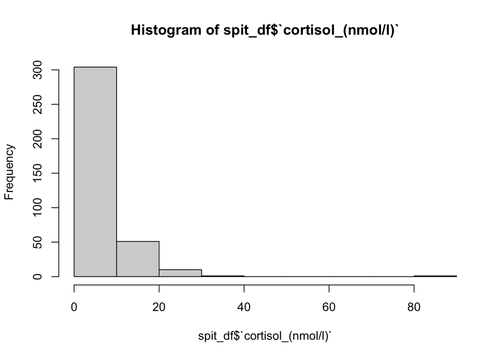

```r
hist(spit_df$`cortisol_(nmol/l)`)
```

```r
summary(spit_df$`dhea_(nmol/l)`)
```

```
##    Min. 1st Qu.  Median    Mean 3rd Qu.    Max.    NA's
##  0.1076  0.3093  0.6121  0.9811  1.2834  5.2050       5
```

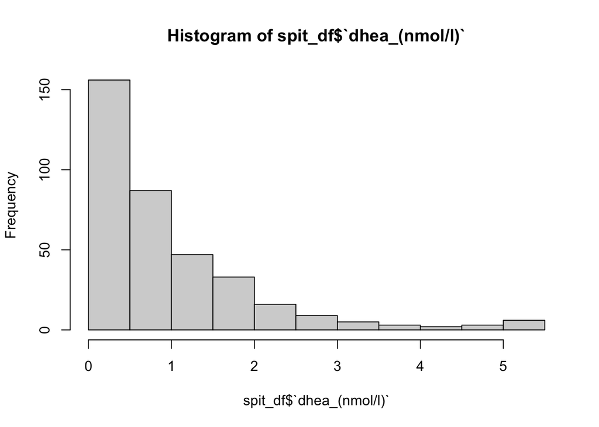

```r
hist(spit_df$`dhea_(nmol/l)`)
```

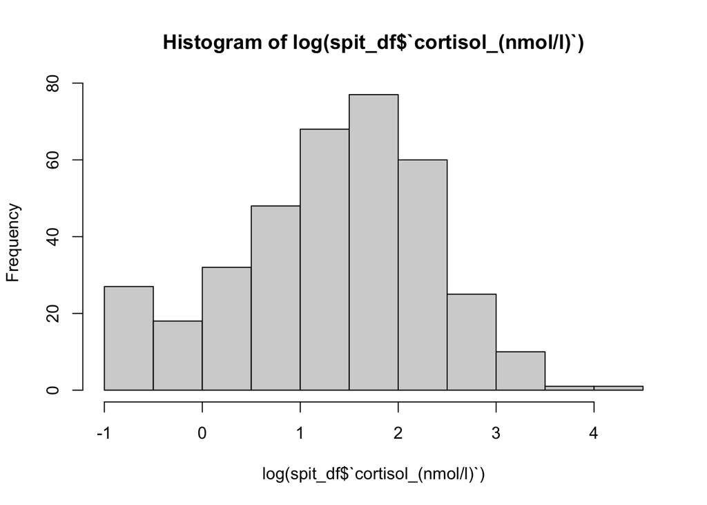

```r
# log-transformed
hist(log(spit_df$`cortisol_(nmol/l)`))
```

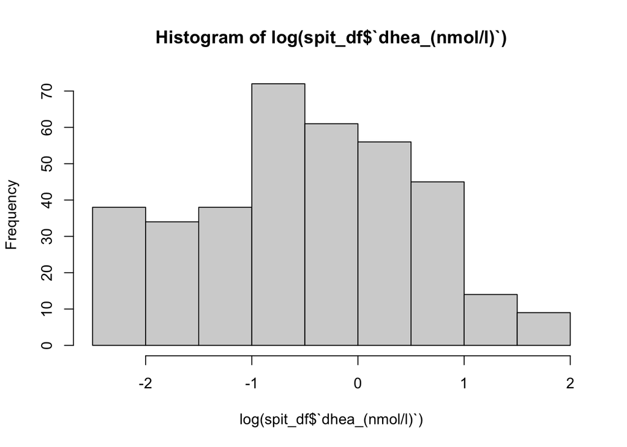

```r
hist(log(spit_df$`dhea_(nmol/l)`))
```

```r
# build cortisol model
cortisol.model <- lmer(log_cortisol ~ t30 + t_after30 +
                   (1|subjectid),
                 data=spit_df_filt)

summary(cortisol.model)
```

```
## Linear mixed model fit by REML. t-tests use Satterthwaite's method [
## lmerModLmerTest]
## Formula: log_cortisol ~ t30 + t_after30 + (1 | subjectid)
##    Data: spit_df_filt
##
## REML criterion at convergence: 775.6
##
## Scaled residuals:
##     Min      1Q  Median      3Q     Max
## -3.1531 -0.5068  0.0402  0.5695  3.9510
##
## Random effects:
##  Groups    Name        Variance Std.Dev.
##  subjectid (Intercept) 0.1147   0.3387
##  Residual              0.5352   0.7316
## Number of obs: 323, groups:  subjectid, 30
##
## Fixed effects:
##               Estimate Std. Error         df t value Pr(>|t|)
## (Intercept)  1.684e+00  1.024e-01  9.086e+01  16.438   <2e-16 ***
## t30          6.134e-03  3.647e-03  2.912e+02   1.682   0.0936 .
## t_after30   -2.231e-03  1.851e-04  2.944e+02 -12.052   <2e-16 ***
## ---
## Signif. codes:  0 '***' 0.001 '**' 0.01 '*' 0.05 '.' 0.1 ' ' 1
##
## Correlation of Fixed Effects:
##           (Intr) t30
## t30       -0.594
## t_after30  0.003 -0.503
```

```r
tidy(cortisol.model, conf.int=T, exponentiate=T)
```

```
## # A tibble: 5 × 10
##   effect   group     term  estimate std.error statistic    df   p.value conf.low
##   <chr>    <chr>     <chr>    <dbl>     <dbl>     <dbl> <dbl>     <dbl>    <dbl>
## 1 fixed    <NA>      (Int…    5.39   0.552        16.4   90.9  5.76e-29    4.40
## 2 fixed    <NA>      t30      1.01   0.00367       1.68 291.   9.36e- 2    0.999
## 3 fixed    <NA>      t_af…    0.998  0.000185    -12.1  294.   1.84e-27    0.997
## 4 ran_pars subjectid sd__…    0.339 NA            NA     NA   NA          NA
## 5 ran_pars Residual  sd__…    0.732 NA            NA     NA   NA          NA
## # ℹ 1 more variable: conf.high <dbl>
```

```r
exp(fixef(cortisol.model))
```

```
## (Intercept)         t30   t_after30
##   5.3871466   1.0061531   0.9977712
```

```r
# quick check of number of patients and
lme4::getME(cortisol.model, "flist") %>%  lapply(nlevels)
```

```
## $subjectid
## [1] 30
```

For nested model (how subjects differ day-to-day) -> singular, with only 3 days not enough to est. * 30 subjects and 86 unique subject-day combinations

t30: * During first 30min of waking, cortisol increases 0.62% per minute * 1.0061531^30 ≈ 1.202049 means cortisol increases by about 20.2% total between waking and 30min

```r
# build DHEA model
DHEA.model <- lmer(log_dhea ~ t30 + t_after30 +
                   (1|subjectid),
                 data=spit_df_filt)

summary(DHEA.model)
```

```
## Linear mixed model fit by REML. t-tests use Satterthwaite's method [
## lmerModLmerTest]
## Formula: log_dhea ~ t30 + t_after30 + (1 | subjectid)
##    Data: spit_df_filt
##
## REML criterion at convergence: 686.1
##
## Scaled residuals:
##     Min      1Q  Median      3Q     Max
## -4.8058 -0.5552  0.0040  0.6025  2.5310
##
## Random effects:
##  Groups    Name        Variance Std.Dev.
##  subjectid (Intercept) 0.2685   0.5181
##  Residual              0.3707   0.6088
## Number of obs: 323, groups:  subjectid, 30
##
## Fixed effects:
##               Estimate Std. Error         df t value Pr(>|t|)
## (Intercept)  2.347e-01  1.167e-01  5.116e+01   2.011   0.0496 *
## t30         -1.824e-02  3.037e-03  2.916e+02  -6.006 5.64e-09 ***
## t_after30   -1.554e-03  1.545e-04  2.937e+02 -10.056  < 2e-16 ***
## ---
## Signif. codes:  0 '***' 0.001 '**' 0.01 '*' 0.05 '.' 0.1 ' ' 1
##
## Correlation of Fixed Effects:
##           (Intr) t30
## t30       -0.433
## t_after30 -0.002 -0.503
```

```r
tidy(DHEA.model, conf.int=T, exponentiate=T)
```

```
## # A tibble: 5 × 10
##   effect   group     term  estimate std.error statistic    df   p.value conf.low
##   <chr>    <chr>     <chr>    <dbl>     <dbl>     <dbl> <dbl>     <dbl>    <dbl>
## 1 fixed    <NA>      (Int…    1.26   0.148         2.01  51.2  4.96e- 2    1.00
## 2 fixed    <NA>      t30      0.982  0.00298      -6.01 292.   5.64e- 9    0.976
## 3 fixed    <NA>      t_af…    0.998  0.000154    -10.1  294.   1.23e-20    0.998
## 4 ran_pars subjectid sd__…    0.518 NA            NA     NA   NA          NA
## 5 ran_pars Residual  sd__…    0.609 NA            NA     NA   NA          NA
## # ℹ 1 more variable: conf.high <dbl>
```

```r
exp(fixef(DHEA.model))
```

```
## (Intercept)         t30   t_after30
##   1.2645875   0.9819271   0.9984475
```

t30: * During first 30min of waking, DHEA decreases by 1.8% per minute * 0.9819271^30 ≈ 0.5786 means DHEA decreases by about 42.1% total between waking and 30min

t_after30: * 1-0.9984475: after 30min, DHEA decreases by about 0.2% per minute * 0.9984475^60 ≈ 0.911 or after 30min, DHEA decreases by about 8.9% per hour

```r
# merge both model outputs into one table for simplicity
tbl_dhea <-
  tbl_regression(
    DHEA.model,
    exponentiate = TRUE,
    intercept = TRUE,
    estimate_fun = label_style_sigfig(digits = 3),
    pvalue_fun = label_style_pvalue(digits = 3),
    label = list(
      t30 ~ "30 min post wake",
      t_after30 ~ "After 30 min"))

tbl_cort <-
  tbl_regression(
    cortisol.model,
    exponentiate = TRUE,
    intercept = TRUE,
    estimate_fun = label_style_sigfig(digits = 4),
    pvalue_fun = label_style_pvalue(digits = 3),
    label = list(
      t30 ~ "30 min post wake",
      t_after30 ~ "After 30 min"))


tbl_merged <-
  tbl_merge(
    tbls = list(tbl_dhea, tbl_cort),
    tab_spanner = c("**DHEA**", "**Cortisol**")) %>%
  as_gt() %>%
  gt::tab_header(
    title = "Diurnal Patterns",
    subtitle = "Piece-wise Linear Mixed-Effects Models w/ Random Intercepts")

tbl_merged
```

Diurnal Patterns

Piece-wise Linear Mixed-Effects Models w/ Random Intercepts

| **Characteristic** | **DHEA** **exp(Beta)** | **DHEA** **95% CI** | **DHEA** **p-value** | **Cortisol** **exp(Beta)** | **Cortisol** **95% CI** | **Cortisol** **p-value** |
| --- | --- | --- | --- | --- | --- | --- |
| (Intercept) | 1.26 | 1.00, 1.60 | 0.050 | 5.387 | 4.395, 6.603 | <0.001 |
| 30 min post wake | 0.982 | 0.976, 0.988 | <0.001 | 1.006 | 0.9990, 1.013 | 0.094 |
| After 30 min | 0.998 | 0.998, 0.999 | <0.001 | 0.9978 | 0.9974, 0.9981 | <0.001 |

Abbreviation: CI = Confidence Interval

## Supplemental

Are rate of change different between the two time-segments?

```r
tr1 <- emtrends(DHEA.model, specs = ~ 1, var = "t30")
tr2 <- emtrends(DHEA.model, specs = ~ 1, var = "t_after30")

# Combine into one object and contrast
tr_both <- rbind(tr1, tr2)
contrast(tr_both, method = list("t30 - t_after30" = c(1, -1)))
```

```
##  contrast        estimate      SE  df t.ratio p.value
##  t30 - t_after30  -0.0167 0.00312 291  -5.352  <.0001
##
## Degrees-of-freedom method: kenward-roger
```

Graph the time trends for cortisol and DHEA

```r
knot <- 30

newdat <- expand.grid(
  time_min = seq(0,
                 max(spit_df_filt$bk_min_since_wk, na.rm = TRUE), by = 1)) %>%
  mutate(
    t30       = pmin(time_min, knot),
    t_after30 = pmax(time_min - knot, 0))

pred_dhea <- newdat %>%
  mutate(
    fit = predict(DHEA.model, newdata = newdat, re.form = NA),
    hormone = "DHEA")

pred_cort <- newdat %>%
  mutate(
    fit = predict(cortisol.model, newdata = newdat, re.form = NA),
    hormone = "Cortisol")

pred_all <- bind_rows(pred_dhea, pred_cort)
```

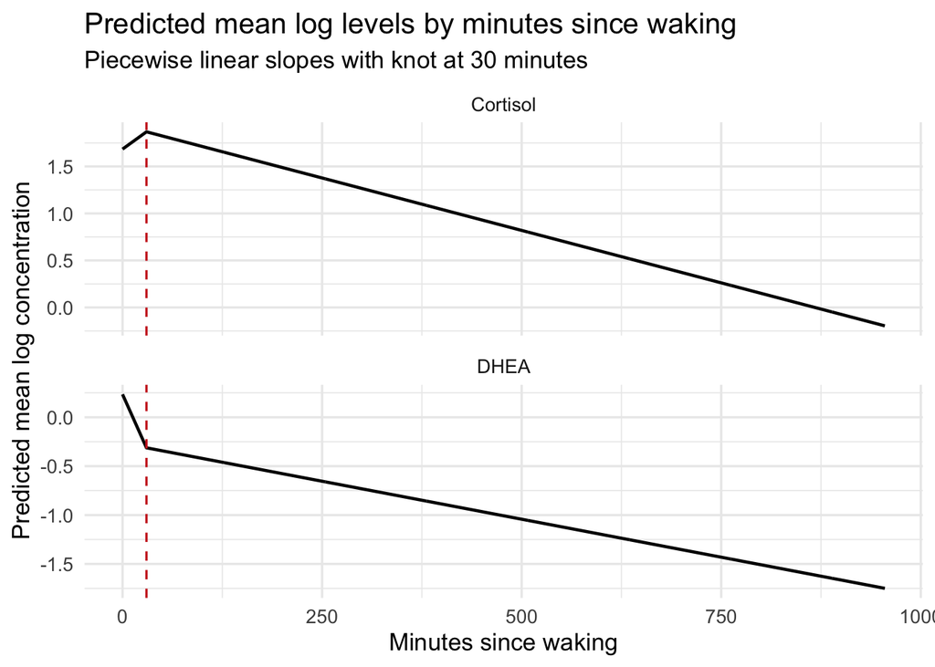

```r
ggplot(pred_all, aes(x = time_min, y = fit)) +
  geom_line(linewidth = 0.8) +
  geom_vline(xintercept = knot, linetype = 2, color = "firebrick3") +
  facet_wrap(~ hormone, scales = "free_y", nrow=2) +
  #coord_cartesian(xlim = c(0, 800)) +
  labs(
    title = "Predicted mean log levels by minutes since waking",
    subtitle = paste0("Piecewise linear slopes with knot at ", knot, " minutes"),
    x = "Minutes since waking",
    y = "Predicted mean log concentration") +
  theme_minimal(base_size = 13)
```